```r
library(dplyr)
```

# Quiz 1

## Question 1

Consider the `mtcars` data set. Fit a model with mpg as the outcome that includes number of cylinders as a factor variable and weight as confounder. Give the adjusted estimate for the expected change in mpg comparing 8 cylinders to 4.

### Answer:

```r
grouped.cars <- mtcars %>% group_by(as.factor(cyl))
```

```r
fit.result <- with(grouped.cars, lm(mpg ~ wt+as.factor(cyl)))
fit.result
```

```
##
## Call:
## lm(formula = mpg ~ wt + as.factor(cyl))
##
## Coefficients:
##     (Intercept)               wt  as.factor(cyl)6  as.factor(cyl)8
##          33.991           -3.206           -4.256           -6.071
```

```r
fit.result$coefficients['as.factor(cyl)8']
```

```
## as.factor(cyl)8
##        -6.07086
```

## Question 2

Consider the mtcars data set. Fit a model with mpg as the outcome that includes number of cylinders as a factor variable and weight as a possible confounding variable. Compare the effect of 8 versus 4 cylinders on mpg for the adjusted and unadjusted by weight models. Here, adjusted means including the weight variable as a term in the regression model and unadjusted means the model without weight included. What can be said about the effect comparing 8 and 4 cylinders after looking at models with and without weight included?.

### Answer:

First, look at the regression where the weight is considered as a confounding factor. This is the same as question 1.

```r
fit.result <- with(grouped.cars, lm(mpg ~ wt+as.factor(cyl)))
fit.result
```

```
##
## Call:
## lm(formula = mpg ~ wt + as.factor(cyl))
##
## Coefficients:
##     (Intercept)               wt  as.factor(cyl)6  as.factor(cyl)8
##          33.991           -3.206           -4.256           -6.071
```

```r
fit.result$coefficients['as.factor(cyl)8']
```

```
## as.factor(cyl)8
##        -6.07086
```

Now, compare this with the scenario where weight isn’t considered.

```r
fit.result <- with(grouped.cars, lm(mpg ~ as.factor(cyl)))
fit.result
```

```
##
## Call:
## lm(formula = mpg ~ as.factor(cyl))
##
## Coefficients:
##     (Intercept)  as.factor(cyl)6  as.factor(cyl)8
##          26.664           -6.921          -11.564
```

```r
fit.result$coefficients['as.factor(cyl)8']
```

```
## as.factor(cyl)8
##       -11.56364
```

When the weight is considered as a confounding factor, the effect of the number of cylinders appears to decrease.

## Question 3

Consider the mtcars data set. Fit a model with mpg as the outcome that considers number of cylinders as a factor variable and weight as confounder. Now fit a second model with mpg as the outcome model that considers the interaction between number of cylinders (as a factor variable) and weight. Give the P-value for the likelihood ratio test comparing the two models and suggest a model using 0.05 as a type I error rate significance benchmark.

### Answer:

First, look at the regression where the weight is considered as a confounding factor. This is the same as question 1.

```r
fit.result.no.interaction <- with(grouped.cars, lm(mpg ~ wt+as.factor(cyl)))
summary(fit.result.no.interaction)
```

```
##
## Call:
## lm(formula = mpg ~ wt + as.factor(cyl))
##
## Residuals:
##     Min      1Q  Median      3Q     Max
## -4.5890 -1.2357 -0.5159  1.3845  5.7915
##
## Coefficients:
##                 Estimate Std. Error t value Pr(>|t|)
## (Intercept)      33.9908     1.8878  18.006  < 2e-16 ***
## wt               -3.2056     0.7539  -4.252 0.000213 ***
## as.factor(cyl)6  -4.2556     1.3861  -3.070 0.004718 **
## as.factor(cyl)8  -6.0709     1.6523  -3.674 0.000999 ***
## ---
## Signif. codes:  0 '***' 0.001 '**' 0.01 '*' 0.05 '.' 0.1 ' ' 1
##
## Residual standard error: 2.557 on 28 degrees of freedom
## Multiple R-squared:  0.8374, Adjusted R-squared:   0.82
## F-statistic: 48.08 on 3 and 28 DF,  p-value: 3.594e-11
```

```r
fit.result.with.interaction <- with(grouped.cars, lm(mpg ~ wt+as.factor(cyl)+wt*as.factor(cyl)))
summary(fit.result.with.interaction)
```

```
##
## Call:
## lm(formula = mpg ~ wt + as.factor(cyl) + wt * as.factor(cyl))
##
## Residuals:
##     Min      1Q  Median      3Q     Max
## -4.1513 -1.3798 -0.6389  1.4938  5.2523
##
## Coefficients:
##                    Estimate Std. Error t value Pr(>|t|)
## (Intercept)          39.571      3.194  12.389 2.06e-12 ***
## wt                   -5.647      1.359  -4.154 0.000313 ***
## as.factor(cyl)6     -11.162      9.355  -1.193 0.243584
## as.factor(cyl)8     -15.703      4.839  -3.245 0.003223 **
## wt:as.factor(cyl)6    2.867      3.117   0.920 0.366199
## wt:as.factor(cyl)8    3.455      1.627   2.123 0.043440 *
## ---
## Signif. codes:  0 '***' 0.001 '**' 0.01 '*' 0.05 '.' 0.1 ' ' 1
##
## Residual standard error: 2.449 on 26 degrees of freedom
## Multiple R-squared:  0.8616, Adjusted R-squared:  0.8349
## F-statistic: 32.36 on 5 and 26 DF,  p-value: 2.258e-10
```

```r
likelihood.ratio.test <- anova(fit.result.no.interaction,
                               fit.result.with.interaction)
likelihood.ratio.test
```

```
## Analysis of Variance Table
##
## Model 1: mpg ~ wt + as.factor(cyl)
## Model 2: mpg ~ wt + as.factor(cyl) + wt * as.factor(cyl)
##   Res.Df    RSS Df Sum of Sq      F Pr(>F)
## 1     28 183.06
## 2     26 155.89  2     27.17 2.2658 0.1239
```

## Question 4

Consider the `mtcars` data set. Fit a model with mpg as the outcome that includes number of cylinders as a factor variable and weight inlcuded in the model as

```
lm(mpg ~ I(wt * 0.5) + factor(cyl), data = mtcars)
```

How is the wt coefficient interpretted?

### Answer:

```r
lm(mpg ~ I(wt * 0.5) + factor(cyl), data = mtcars)
```

```
##
## Call:
## lm(formula = mpg ~ I(wt * 0.5) + factor(cyl), data = mtcars)
##
## Coefficients:
##  (Intercept)   I(wt * 0.5)  factor(cyl)6  factor(cyl)8
##       33.991        -6.411        -4.256        -6.071
```

Since the `wt` column is given in units of 1000 lbs, the above linear model gives “The estimated expected change in MPG per one ton increase in weight for a specific number of cylinders (4, 6, 8).”

I’m not sure I completely buy this because the same slope is used for all number of cylinders.

## Question 5

Consider the following data set

```r
x <- c(0.586, 0.166, -0.042, -0.614, 11.72)
y <- c(0.549, -0.026, -0.127, -0.751, 1.344)
```

Give the hat diagonal for the most influential point

### Answer:

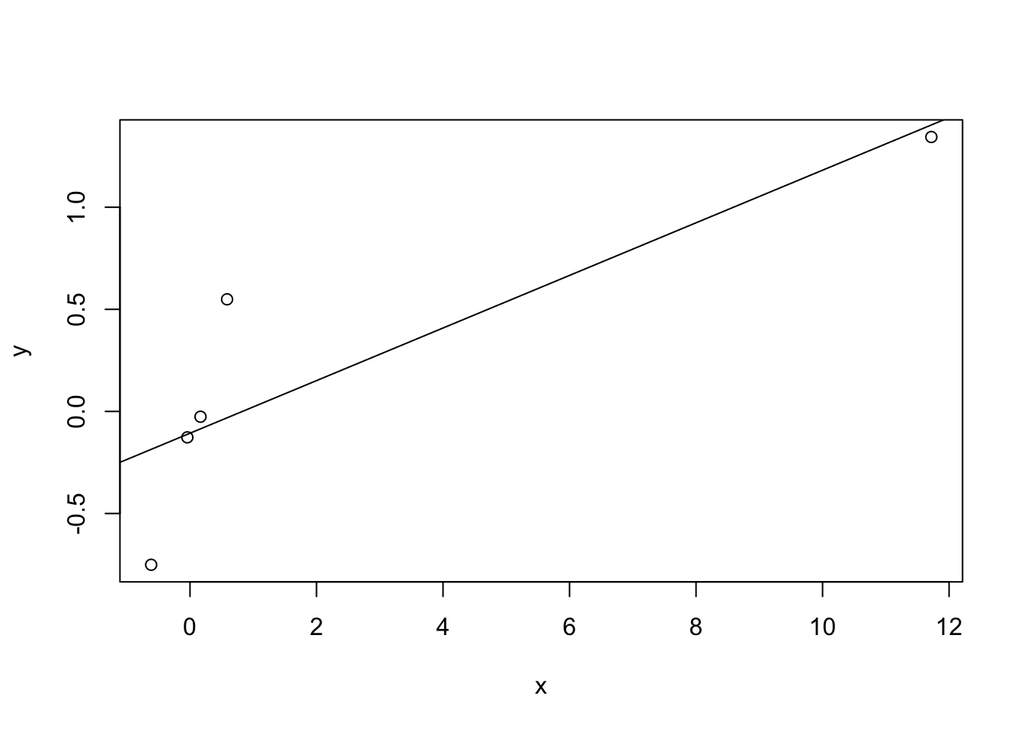

```r
fit <- lm(y~x)
plot(y~x)
abline(fit)
```

```r
hatvalues(fit)
```

```
##         1         2         3         4         5
## 0.2286650 0.2438146 0.2525027 0.2804443 0.9945734
```

## Question 6

Consider the following data set

```r
x <- c(0.586, 0.166, -0.042, -0.614, 11.72)
y <- c(0.549, -0.026, -0.127, -0.751, 1.344)
```

Give the slope dfbeta for the point with the highest hat value.

### Answer:

```r
dfbetas(fit)
```

```
##   (Intercept)             x
## 1  1.06212391   -0.37811633
## 2  0.06748037   -0.02861769
## 3 -0.01735756    0.00791512
## 4 -1.24958248    0.67253246
## 5  0.20432010 -133.82261293
```

## Question 7

Consider a regression relationship between Y and X with and without adjustment for a third variable Z. Which of the following is true about comparing the regression coefficient between Y and X with and without adjustment for Z.

### Answer:

For the the coefficient to change sign, there must be a significant interaction term.